# DAT-204 - R for Data Analytics: Final Project

Zach Trozenski

12/8/2020

### An analysis of the previous 5 years worth of storm events

#### Introduction

For my final project I wanted to revisit a data set I had originally queried for DAT-202 from the National Climatic Data Center (NCDC) [Storm Events Database.](https://www.ncdc.noaa.gov/stormevents/choosedates.jsp?statefips=42%2CPENNSYLVANIA#) The data set was composed of self-selected severe weather events for a given time range in a given area. When I ran the query to create this data set it was with the purpose of attempting to forecast severe weather based on historical data, however my plans changed and I chose to forecast a different data set still within the weather domain (as it turns out forecasting rain is best left to the professionals). Revisiting the storm events data presented a good opportunity however to conduct analysis in R.

Here are some of the questions I was hoping to answer:

- Which storm events were the most common in our area over the past five years?
- How much damage (as measured in USD) do these storms cause on average?
- When did the most destructive storms occur?
  - Does the data indicate they are increasing?
- In the data set, is there a correlation between storm severity and damage in USD?
- Who reports and documents the storms?
  - Are there any observable changes over time?

Please note the code is not being echoed in the markdown document for brevity and cleanliness. It is posted on my Github account here. For reference here is the [data dictionary,](https://www1.ncdc.noaa.gov/pub/data/swdi/stormevents/csvfiles/Storm-Data-Export-Format.pdf)

### Most common storms in our area

Using a combination of a `for` loop and the `unique()` function I created a dataframe of the total counts of all storm events in descending order:

```
##             Weather.Event Total.Count
## 2       Thunderstorm Wind         182
## 4             Flash Flood         167
## 5                   Flood          48
## 6              Heavy Rain          18
## 1 Extreme Cold/Wind Chill           5
## 3             Strong Wind           4
## 9               High Wind           3
## 7              Heavy Snow           2
## 8            Winter Storm           2
```

The most common storm events in our area over the previous 5 years have been Thunderstorm Winds and Flash Floods. The two events seem to go hand in hand, as it suggests that thunderstorms can cause both the high damaging winds as well as flash floods. (Please note the index at the far left of the data frame is the original order in which the events were listed and doesn’t factor into the count.)

Now that we know the most common storm events let’s shift our focus onto the damage they can cause.

### Storm destruction measured in dollars

The data set contains estimations for the total amount of crop and property damage a storm event caused. Additionally the data set also accounts for injuries and deaths directly caused by the storm. Luckily the number of injuries and deaths relative to the total number of storm events logged is low. Instead let’s focus on the damage estimates.

To get a total count of each storm event’s estimated damage, I created a new series in the data frame which summed the crop and property damage estimates and added it to my original data frame. From there I ran the `summary()` function to get descriptive statistics on the the total estimates of storm event damage.

```
##     Min.  1st Qu.   Median     Mean  3rd Qu.     Max.
##        0        0     1000    33262     5000 10100000
```

```
## [1] "Standard deviation: " "491486.882977695"
```

The descriptive statistics indicate that the most of the estimates are quite low coming in at $1000 USD. What is interesting is that the Maximum value, which taken into consideration with the median and mean values seem to indicate it is an extreme outlier which would also explain the mean value being much higher than the 3rd quartile and the median. I think it would be helpful to visualize the distribution of the total storm damage to augment our understanding of the descriptive statistics.

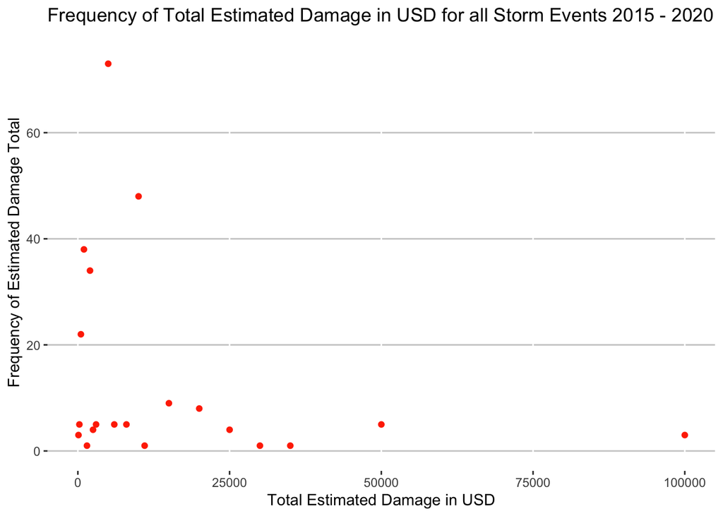

Based on this plot we can see that our assumptions about the distribution of data, that it’s concentrated heavily at the lower range. Given the descriptive statistics together with the plot we can assume that a given severe storm event won’t cause an extreme amount of damage. While that may be the case, we only know the frequency of a storms damage. We don’t know if the damage is increasing over time or when the most severe storms occurred.

### Most destructive storms in the data set

Let’s create a subset of the data to only look at the most destructive storms and see if we can detect any patterns. First, we’ll slice our data set by pulling all storms that have total storm damage higher than the mean of $33,262. I noticed when I was plotting this subset that the maximum value was creating some difficulty in making the graph legible, so I scaled the the total damage so that it would reflect values in millions of dollars rather than the absolute value.

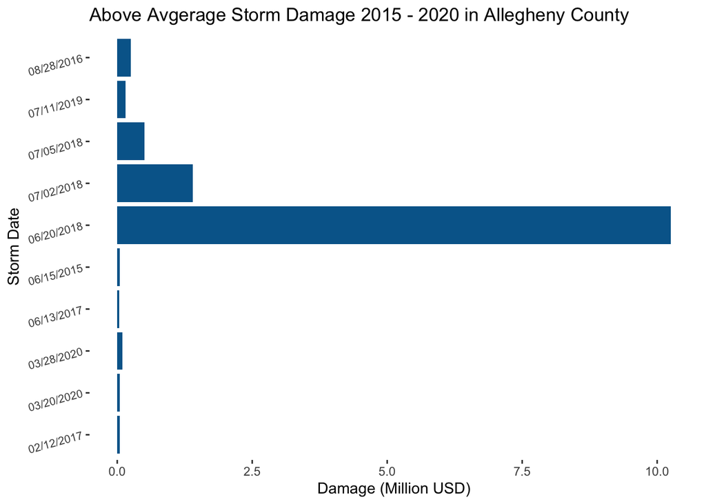

```
##     BEGIN_LOCATION BEGIN_DATE        EVENT_TYPE MAGNITUDE FLOOD_CAUSE
## 47        CHESWICK 06/15/2015       Flash Flood        NA  Heavy Rain
## 128     SHARPSBURG 08/28/2016       Flash Flood        NA  Heavy Rain
## 131                02/12/2017       Strong Wind        48
## 148        LINCOLN 06/13/2017 Thunderstorm Wind        50
## 242           ROOK 06/20/2018       Flash Flood        NA  Heavy Rain
## 245        DORMONT 06/20/2018       Flash Flood        NA  Heavy Rain
## 247          BOYCE 06/20/2018       Flash Flood        NA  Heavy Rain
## 251    HARMERVILLE 07/02/2018       Flash Flood        NA  Heavy Rain
## 265  BERKLEY HILLS 07/05/2018       Flash Flood        NA  Heavy Rain
## 358    ANDERSON RD 07/11/2019       Flash Flood        NA  Heavy Rain
## 360    BETHEL PARK 07/11/2019       Flash Flood        NA  Heavy Rain
## 407        BLAWNOX 03/20/2020             Flood        NA  Heavy Rain
## 408          EHAMA 03/28/2020       Flash Flood        NA  Heavy Rain
##     END_LOCATION BEGIN_LAT BEGIN_LON END_LAT  END_LON
## 47      CHESWICK   40.5401  -79.8048 40.5423 -79.8037
## 128    ASPINWALL   40.4845  -79.9064 40.4806 -79.9062
## 131                     NA        NA      NA       NA
## 148      LINCOLN   40.3300  -79.8600 40.3300 -79.8600
## 242    WOODVILLE   40.4000  -80.0800 40.3890 -80.0845
## 245      DORMONT   40.4000  -80.0400 40.3974 -80.0334
## 247      LIBRARY   40.3190  -80.0756 40.3090 -80.0611
## 251  SANDY CREEK   40.5458  -79.8683 40.4899 -79.8629
## 265  CHERRY CITY   40.5100  -79.9900 40.4785 -79.9652
## 358 FOREST GROVE   40.5707  -80.2168 40.4937 -80.1293
## 360       WILSON   40.3200  -80.0400 40.3199 -79.9259
## 407         PLUM   40.5100  -79.8500 40.4382 -79.7139
## 408      WALLACE   40.2424  -79.9194 40.2432 -80.0020
```

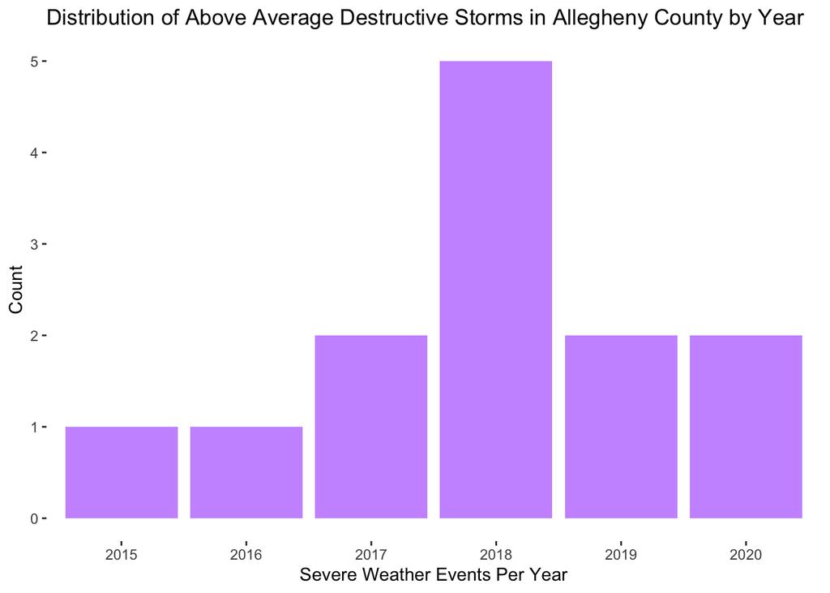